# Predicting Car Sales

```python
# values look plausible, except MMR features: there are purchase prices of 0 Dollar - check how many and whether to replace:
```

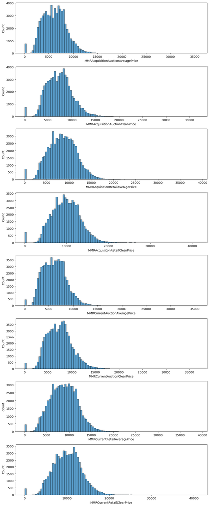

```python
features_mmr = ['MMRAcquisitionAuctionAveragePrice',
                'MMRAcquisitionAuctionCleanPrice', 'MMRAcquisitionRetailAveragePrice',
                'MMRAcquisitonRetailCleanPrice', 'MMRCurrentAuctionAveragePrice',
                'MMRCurrentAuctionCleanPrice', 'MMRCurrentRetailAveragePrice',
                'MMRCurrentRetailCleanPrice']

fig, ax = plt.subplots(nrows=len(features_mmr), figsize=(10, len(features_mmr) * 3))

for i, col in enumerate(features_mmr):
    sns.histplot(df[col], bins=100, ax=ax[i])

plt.tight_layout()
plt.show()
```

```python
# Count number of 0 Dollar purchase prices per row:
zero_purch_row = (df[features_mmr] == 0).sum(axis=1)
print(zero_purch_row.value_counts().sort_index())
```

```
0    64837
3       18
4      358
6      110
8      297
Name: count, dtype: int64
```

```python
# purchase prices of 0 Dollar mostly occur in several MMR features at the same time.
# these cases could be deleted row-wise or the values be replaced by the median (which is actually done below)
```

```python
#checking the frequencies of categorical features

print(df[features_cat].nunique())

for col in features_cat:
    print(f'=== {col} ===')
    counts = df[col].value_counts().to_frame('frequency')
    counts['percent'] = (df[col].value_counts(normalize=True)*100).round(2)
    print(counts)
    print()
```

```
Auction                  3
Make                    29
Color                   16
Transmission             3
WheelType                4
Nationality              4
Size                    12
TopThreeAmericanName     4
VNST                    34
dtype: int64
=== Auction ===
         frequency  percent
Auction
MANHEIM      36907    56.24
OTHER        15675    23.89
ADESA        13038    19.87

=== Make ===
            frequency  percent
Make
CHEVROLET       15581    23.74
DODGE           11597    17.67
FORD            10167    15.49
CHRYSLER         7953    12.12
PONTIAC          3823     5.83
KIA              2243     3.42
SATURN           1968     3.00
NISSAN           1860     2.83
HYUNDAI          1605     2.45
JEEP             1477     2.25
SUZUKI           1196     1.82
TOYOTA           1018     1.55
MITSUBISHI        922     1.41
MAZDA             883     1.35
MERCURY           810     1.23
BUICK             656     1.00
GMC               578     0.88
HONDA             451     0.69
OLDSMOBILE        215     0.33
ISUZU             125     0.19
```

[output cut: 99 more lines]

```
IN          445     0.68
MS          428     0.65
IL          416     0.63
LA          319     0.49
NJ          298     0.45
WV          261     0.40
NM          217     0.33
KY          214     0.33
OR          193     0.29
ID          179     0.27
WA          117     0.18
NH           87     0.13
AR           65     0.10
MN           56     0.09
NE           25     0.04
```

```python
# transmission is nearly a constant - can be left out
# merge categories because of low frequencies: VNST, Color, Make
```

```python
#correlations and detecting outliers
```

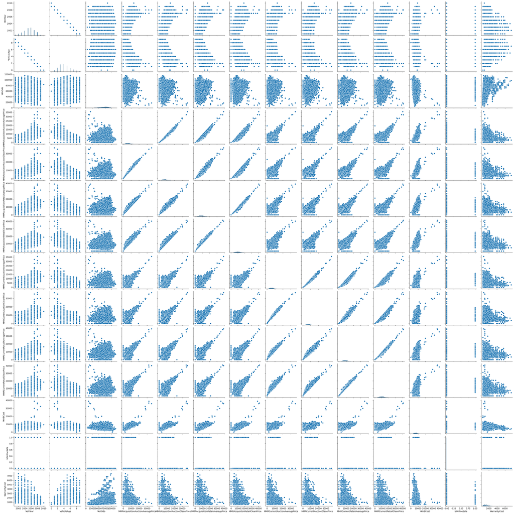

```python
sns.pairplot(df[features_num])
plt.savefig('pairplot.png', dpi=300, bbox_inches='tight')
plt.show()
```

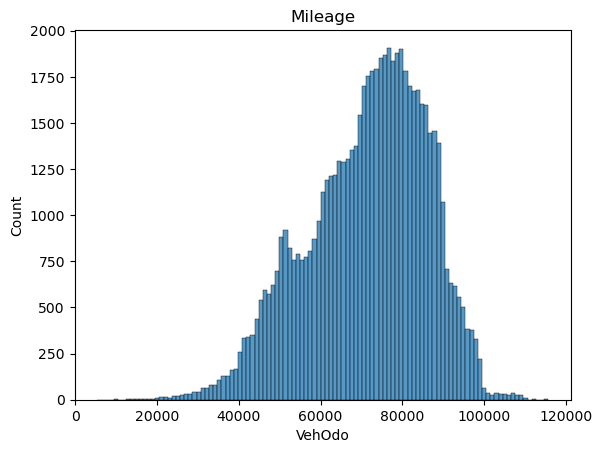

```python
# some outliers appear:
    # VehBCost: starting from around 20 000 Dollar
    # MMR features: starting from around 25 000 Dollar
    # Mileage: the lower the mileage the higher the price, but there only few cars with low mileage
sns.histplot(df['VehOdo'])
plt.title("Mileage")
plt.show()
```

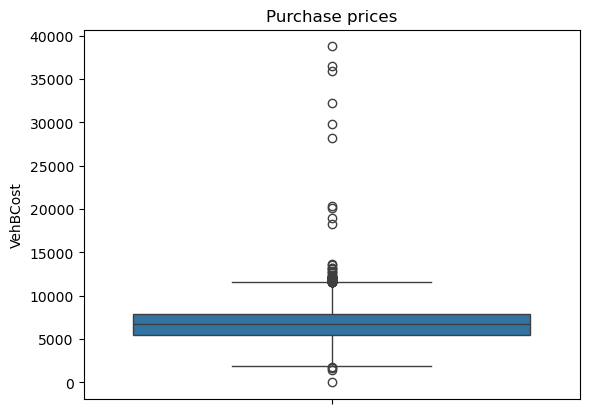

```python
# Visualizing the outliers in VehBCost - Price that the used car dealer paid for the vehicle
sns.boxplot(df['VehBCost'])
plt.title("Purchase prices")
plt.show()
```

```python
# VehBCost contains a lot of outliers that will be treated during data preparation (see below)
```

**To do during data preparation:**

0. Object format in category
1. MMR features and VehBCost: impute zeros and missings with median
2. Apply: class_weights = balanced
3. WheelType: set missings as own category
4. Impute missings with modus: Color, Nationality, Size, TopThreeAmericanName
5. Drop features not appropriate for this project: Model, SubModel, Trim, PRIMEUNIT, AUCGUART, Transmission, WheelTypeID, BYRNO
6. Merge low frequency categories: VNST, Color, Make
7. Trim outliers using median absolute deviation (mad): VehBCost

# **Train-Test-Split**

```python
df = pd.read_csv('data_train.csv')

# perform train-test-split
from sklearn.model_selection import train_test_split

features = df.drop(columns='IsBadBuy')
target = df['IsBadBuy']
features_train, features_test, target_train, target_test = train_test_split(features, target,
                                                                            random_state = 42, test_size = 0.1)
```

```python
# save features_test as 'features_test.csv'
features_test.to_csv('features_test.csv', index=False)
```

## Data Preparation

### Datatype Transformation

```python
df = features_train.copy()
df['PurchDate'] = pd.to_datetime(df['PurchDate'], unit='s')

df = df.drop(columns=['Model', 'SubModel', 'Trim', 'Transmission', 'PRIMEUNIT', 'AUCGUART', 'WheelTypeID', 'BYRNO'])
feature_obj = ['Auction', 'Make', 'Color', 'WheelType',
              'Nationality', 'Size', 'TopThreeAmericanName', 'VNST']
df[feature_obj] = df[feature_obj].astype('category')

df.dtypes
```

```
PurchDate                            datetime64[ns]
Auction                                    category
VehYear                                       int64
VehicleAge                                    int64
Make                                       category
Color                                      category
WheelType                                  category
VehOdo                                        int64
Nationality                                category
Size                                       category
TopThreeAmericanName                       category
MMRAcquisitionAuctionAveragePrice           float64
MMRAcquisitionAuctionCleanPrice             float64
MMRAcquisitionRetailAveragePrice            float64
MMRAcquisitonRetailCleanPrice               float64
MMRCurrentAuctionAveragePrice               float64
MMRCurrentAuctionCleanPrice                 float64
MMRCurrentRetailAveragePrice                float64
MMRCurrentRetailCleanPrice                  float64
VNZIP1                                        int64
VNST                                       category
VehBCost                                    float64
IsOnlineSale                                  int64
WarrantyCost                                  int64
dtype: object
```

### Data Imputation

```python
df.isna().sum()
```

```
PurchDate                               0
Auction                                 0
VehYear                                 0
VehicleAge                              0
Make                                    0
Color                                   7
WheelType                            2608
VehOdo                                  0
Nationality                             4
Size                                    4
TopThreeAmericanName                    4
MMRAcquisitionAuctionAveragePrice      15
MMRAcquisitionAuctionCleanPrice        15
MMRAcquisitionRetailAveragePrice       15
MMRAcquisitonRetailCleanPrice          15
MMRCurrentAuctionAveragePrice         261
MMRCurrentAuctionCleanPrice           261
MMRCurrentRetailAveragePrice          261
MMRCurrentRetailCleanPrice            261
VNZIP1                                  0
VNST                                    0
VehBCost                               51
IsOnlineSale                            0
WarrantyCost                            0
dtype: int64
```

```python
df['WheelType'] = df['WheelType'].cat.add_categories('unknown').fillna('unknown')
df['WheelType'].unique()
```

```
['Covers', 'Alloy', 'unknown', 'Special']
Categories (4, object): ['Alloy', 'Covers', 'Special', 'unknown']
```

```python
#replace zeros and 1 Dollar purchase prices (symbolic value for given.away cars) with median:
#before: define them as missings in order to replace together with other missings

null_cols = ['MMRAcquisitionAuctionAveragePrice',
                'MMRAcquisitionAuctionCleanPrice', 'MMRAcquisitionRetailAveragePrice',
                'MMRAcquisitonRetailCleanPrice', 'MMRCurrentAuctionAveragePrice',
                'MMRCurrentAuctionCleanPrice', 'MMRCurrentRetailAveragePrice',
                'MMRCurrentRetailCleanPrice', 'VehBCost']
df[null_cols] = df[null_cols].replace([0, 1], np.nan)
df = df.fillna(df.median(numeric_only=True))
```

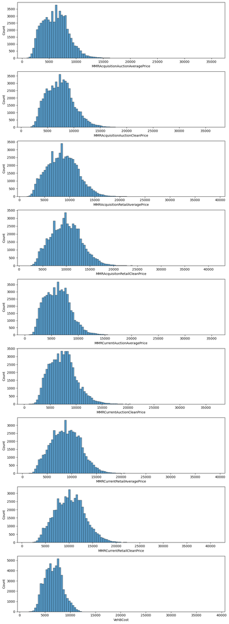

```python
#Check whether the features still contain zero values:
fig, ax = plt.subplots(nrows=len(null_cols), figsize=(10, len(null_cols) * 3))

for i, col in enumerate(null_cols):
    sns.histplot(df[col], bins=100, ax=ax[i])

plt.tight_layout()
plt.show()
```

```python
#replace missings in categorical features with modus
cat_cols = df.select_dtypes(include=['category']).columns
df[cat_cols] = df[cat_cols].fillna(df[cat_cols].mode().iloc[0])
df.isna().sum()
```

```
PurchDate                            0
Auction                              0
VehYear                              0
VehicleAge                           0
Make                                 0
Color                                0
WheelType                            0
VehOdo                               0
Nationality                          0
Size                                 0
TopThreeAmericanName                 0
MMRAcquisitionAuctionAveragePrice    0
MMRAcquisitionAuctionCleanPrice      0
MMRAcquisitionRetailAveragePrice     0
MMRAcquisitonRetailCleanPrice        0
MMRCurrentAuctionAveragePrice        0
MMRCurrentAuctionCleanPrice          0
MMRCurrentRetailAveragePrice         0
MMRCurrentRetailCleanPrice           0
VNZIP1                               0
VNST                                 0
VehBCost                             0
IsOnlineSale                         0
WarrantyCost                         0
dtype: int64
```

### Deal with outliers

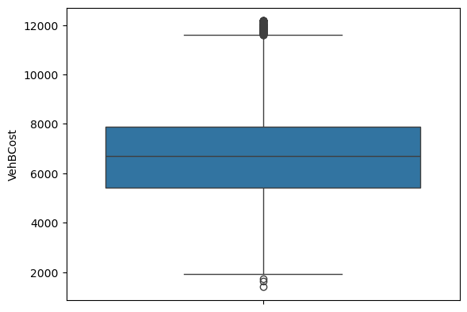

```python
# trim outliers in VehBCost (Winsorizing) to median absolute deviance (mad) * 3.

from statsmodels.robust import mad

median = df['VehBCost'].median()

lower = median - 3 * mad(df['VehBCost'])
upper = median + 3 * mad(df['VehBCost'])

df['VehBCost'] = df['VehBCost'].clip(lower=lower, upper=upper)

import seaborn as sns

sns.boxplot(df['VehBCost'])
```

Summarizing all data cleaning steps in one function that considers the train-test-split logic to prevent data leakage.

```python
def clean_data(df, median=None, mode=None, mad=None, outlier_col=None):
    '''
    Function to select columns, transform data types, deal with missings and outliers
    input: features_train or features_test, median, mode, mad from train data if applied on test data;
            outlier_col: columns for which outliers shall be trimmed to 3 * mad
    output: clean features_train, ready for model training + median, mode, mad for usage on test data;
            clean features_test
    '''

    df = df.copy() # to prevent warnings

    from scipy.stats import median_abs_deviation

    # calculate median, mode and mad from train data
    if median is None:
        median = df.median(numeric_only=True)
    if mode is None:
        mode = df.mode().iloc[0]
    if mad is None:
        mad = df.select_dtypes(include='number').apply(median_abs_deviation)

    # format date time column
    df['PurchDate'] = pd.to_datetime(df['PurchDate'], unit='s')

    # remove unnecessary columns
    df = df.drop(columns=['Model', 'SubModel', 'Trim', 'Transmission', 'PRIMEUNIT', 'AUCGUART', 'WheelTypeID', 'BYRNO'])

    # change data type object in category
    feature_obj = ['Auction', 'Make', 'Color', 'WheelType',
              'Nationality', 'Size', 'TopThreeAmericanName', 'VNST']
    df[feature_obj] = df[feature_obj].astype('category')

    ### Deal with Missings

    # 1. Missings in WheelType as own category:
    df['WheelType'] = df['WheelType'].cat.add_categories('unknown').fillna('unknown')

    # 2. Replace missings in numerical features with median

        #before: set 0 and 1 Dollar as missings
    null_cols = ['MMRAcquisitionAuctionAveragePrice',
                'MMRAcquisitionAuctionCleanPrice', 'MMRAcquisitionRetailAveragePrice',
                'MMRAcquisitonRetailCleanPrice', 'MMRCurrentAuctionAveragePrice',
                'MMRCurrentAuctionCleanPrice', 'MMRCurrentRetailAveragePrice',
                'MMRCurrentRetailCleanPrice', 'VehBCost']

    import numpy as np
    df[null_cols] = df[null_cols].replace([0, 1], np.nan)

        # Replace missings of nummerical features with median (calculated from train data)
    df = df.fillna(median)

    # 3. Categorical features: replace missings with modus (calculated from train data)
    cat_cols = df.select_dtypes(include=['category']).columns
    df[cat_cols] = df[cat_cols].fillna(mode)

    # Trim Outliers (winsorizing) in VehBCost using median and mad from train data
    if outlier_col is not None:
        lower = median[outlier_col] - 3 * mad[outlier_col]
        upper = median[outlier_col] + 3 * mad[outlier_col]
        df[outlier_col] = df[outlier_col].clip(lower=lower, upper=upper)

    return df, median, mode, mad
```

Check whether clean function works:

```python
import pandas as pd

df = pd.read_csv('data_train.csv')

# perform train-test-split
from sklearn.model_selection import train_test_split

features = df.drop(columns='IsBadBuy')
target = df['IsBadBuy']
features_train, features_test, target_train, target_test = train_test_split(features, target,
                                                                            random_state = 42, test_size = 0.1)

features_train, median, mode, mad = clean_data(features_train, outlier_col='VehBCost')
features_train.info()
```

```
<class 'pandas.core.frame.DataFrame'>
Index: 59058 entries, 21430 to 15795
Data columns (total 24 columns):
 #   Column                             Non-Null Count  Dtype
---  ------                             --------------  -----
 0   PurchDate                          59058 non-null  datetime64[ns]
 1   Auction                            59058 non-null  category
 2   VehYear                            59058 non-null  int64
 3   VehicleAge                         59058 non-null  int64
 4   Make                               59058 non-null  category
 5   Color                              59058 non-null  category
 6   WheelType                          59058 non-null  category
 7   VehOdo                             59058 non-null  int64
 8   Nationality                        59058 non-null  category
 9   Size                               59058 non-null  category
```

[output cut: 16 more lines]

```python
features_test, median, mode, mad  = clean_data(features_test, median, mode, mad, outlier_col='VehBCost')
features_test.info()
```

```
<class 'pandas.core.frame.DataFrame'>
Index: 6562 entries, 37974 to 54473
Data columns (total 24 columns):
 #   Column                             Non-Null Count  Dtype
---  ------                             --------------  -----
 0   PurchDate                          6562 non-null   datetime64[ns]
 1   Auction                            6562 non-null   category
 2   VehYear                            6562 non-null   int64
 3   VehicleAge                         6562 non-null   int64
 4   Make                               6562 non-null   category
 5   Color                              6562 non-null   category
 6   WheelType                          6562 non-null   category
 7   VehOdo                             6562 non-null   int64
 8   Nationality                        6562 non-null   category
 9   Size                               6562 non-null   category
```

[output cut: 16 more lines]

## Modeling

### Build a simple Baselinemodel - logistic regression

```python
# define num_cols and cat_cols
num_cols = ['VehicleAge', 'VehOdo', 'WarrantyCost']
cat_cols = ['Auction', 'WheelType', 'Nationality', 'TopThreeAmericanName']

# for later use:
features_mmr = ['MMRAcquisitionAuctionAveragePrice','MMRAcquisitionAuctionCleanPrice',
                'MMRAcquisitionRetailAveragePrice',
                'MMRAcquisitonRetailCleanPrice', 'MMRCurrentAuctionAveragePrice',
                'MMRCurrentAuctionCleanPrice', 'MMRCurrentRetailAveragePrice',
                'MMRCurrentRetailCleanPrice']
```

```python
# build pipeline

from sklearn.compose import ColumnTransformer
from sklearn.preprocessing import OneHotEncoder

#Apply OneHotEncoder only to cat_cols (to create what is know in data analytics as dummy variables), leave num_cols unchanged

ct_ohe = ColumnTransformer(transformers=[
    ('onehot',      OneHotEncoder(), cat_cols),
    ('passthrough', 'passthrough',   num_cols)
], remainder='drop')

features_train_transformed = ct_ohe.fit_transform(features_train)
features_test_transformed = ct_ohe.transform(features_test)

# resemble column names
ohe_cols = ct_ohe.named_transformers_['onehot'].get_feature_names_out(cat_cols)
all_cols = list(ohe_cols) + list(num_cols)

# Create DataFrames with transformed columns
features_train_transformed = pd.DataFrame(features_train_transformed, columns=all_cols)
features_test_transformed  = pd.DataFrame(features_test_transformed,  columns=all_cols)

print(ohe_cols)
print(features_train_transformed.shape)
print(features_test_transformed.shape)

# Save
import pickle
pickle.dump(ct_ohe, open("ct_ohe.p","wb"))
pickle.dump(ohe_cols, open("ohe_cols.p","wb"))
```

```
['Auction_ADESA' 'Auction_MANHEIM' 'Auction_OTHER' 'WheelType_Alloy'
 'WheelType_Covers' 'WheelType_Special' 'WheelType_unknown'
 'Nationality_AMERICAN' 'Nationality_OTHER' 'Nationality_OTHER ASIAN'
 'Nationality_TOP LINE ASIAN' 'TopThreeAmericanName_CHRYSLER'
 'TopThreeAmericanName_FORD' 'TopThreeAmericanName_GM'
 'TopThreeAmericanName_OTHER']
(59058, 18)
(6562, 18)
```

```python
# instantiate model
from sklearn.linear_model import LogisticRegression
from sklearn.preprocessing import StandardScaler
from sklearn.pipeline import Pipeline
from sklearn.metrics import precision_score, recall_score, f1_score

model_baseline = LogisticRegression(class_weight = 'balanced', random_state=42)
pipeline = Pipeline(steps=[
    ('std', StandardScaler()),
    ('log', model_baseline)
])

# fit pipeline on cleaned (and filtered) training set
pipeline.fit(features_train_transformed, target_train)

# predict and evaluate on test set
result_log = pipeline.predict(features_test_transformed)
#result_log_proba = pipeline.predict_proba(features_test_transformed)

precision = precision_score(target_test, result_log)
recall = recall_score(target_test, result_log)
f1 = f1_score(target_test, result_log)

print('precision: ', precision)
print('recall: ', recall)
print('f1: ', f1)
```

```
precision:  0.2690124858115778
recall:  0.5602836879432624
f1:  0.36349693251533743
```

**Interpretation:**

- Minimize bad purchases (“lemons”): high recall score (actual “lemons” correctly predicted)
- Maximize Sales: high precision score (predicted “lemons” are actual “lemons”)

The simple baseline model predicts 56% of the actual “lemons” correctly. However, only 27% of the predicted “lemons” are actually “lemons” - the used car dealer would miss out on lucrative deals The weighted harmonic mean from recall and precision (f1) is 0.36

**-> using already this simple model can save the company more than half of the losses caused by bad buys!**

### Feature Engineering

```python
# Make, Size and Color: merge categories

cat_feat_engi = ['Make', 'Size', 'Color']

for col in cat_feat_engi:
    print(f'=== {col} ===')
    counts = features_train[col].value_counts().to_frame('frequency')
    counts['relative'] = features_train[col].value_counts(normalize=True)
    print(counts)
    print()

# Make: first four categories + all others as fifth = others
# Size: first five categories + all others as sixth = others
# Color: first five categories + all others as sixth = others

# Recode using .apply und lambda
# logical meaning:
'''
if x in Colortop5:
    return x        # keep value
else:
    return 'other'  # replace value with 'other'
'''

Maketop4 = features_train['Make'].value_counts().nlargest(4).index.tolist()
features_train['Make_r'] = features_train['Make'].apply(lambda x: x if x in Maketop4 else 'other')

Sizetop5 = features_train['Size'].value_counts().nlargest(5).index.tolist()
features_train['Size_r'] = features_train['Size'].apply(lambda x: x if x in Sizetop5 else 'other')

Colortop5 = features_train['Color'].value_counts().nlargest(5).index.tolist()
features_train['Color_r'] = features_train['Color'].apply(lambda x: x if x in Colortop5 else 'other')

cat_feat_engi_r = ['Make_r', 'Size_r', 'Color_r']

for col in cat_feat_engi_r:
    print(f'=== {col} ===')
    counts = features_train[col].value_counts().to_frame('frequency')
    counts['relative'] = features_train[col].value_counts(normalize=True)
    print(counts)
    print()
```

```
=== Make ===
            frequency  relative
Make
CHEVROLET       14010  0.237224
DODGE           10456  0.177046
FORD             9121  0.154441
CHRYSLER         7184  0.121643
PONTIAC          3417  0.057858
KIA              2016  0.034136
SATURN           1757  0.029750
NISSAN           1683  0.028497
HYUNDAI          1445  0.024467
JEEP             1335  0.022605
SUZUKI           1076  0.018219
TOYOTA            930  0.015747
MITSUBISHI        820  0.013885
MAZDA             799  0.013529
MERCURY           739  0.012513
BUICK             599  0.010143
GMC               517  0.008754
HONDA             405  0.006858
OLDSMOBILE        190  0.003217
ISUZU             117  0.001981
VOLKSWAGEN        108  0.001829
SCION              99  0.001676
LINCOLN            82  0.001388
INFINITI           34  0.000576
VOLVO              32  0.000542
ACURA              25  0.000423
SUBARU             24  0.000406
MINI               20  0.000339
LEXUS              18  0.000305

=== Size ===
             frequency  relative
Size
MEDIUM           24939  0.422280
LARGE             7152  0.121101
MEDIUM SUV        6592  0.111619
COMPACT           5841  0.098903
```

[output cut: 42 more lines]

```
other            9789  0.165752
LARGE            7152  0.121101
MEDIUM SUV       6592  0.111619
COMPACT          5841  0.098903
VAN              4745  0.080345

=== Color_r ===
         frequency  relative
Color_r
other        16304  0.276068
SILVER       12114  0.205120
WHITE         9748  0.165058
BLUE          8367  0.141674
GREY          6371  0.107877
BLACK         6154  0.104203
```

```
count    59058.000000
mean         0.205896
std          0.130613
min          0.019554
25%          0.122468
50%          0.177072
75%          0.251613
max          3.016837
Name: Warr/Cost, dtype: float64
```

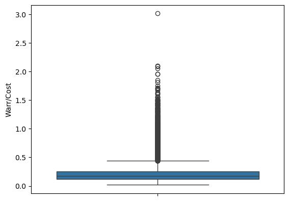

```python
# Creating a new feature: Percentage of warranty costs (WarrantyCost) relative to purchase price (VehBCost)
# the lower the proportion the better the car is evaluated by the insurance (and thus better resalable).

features_train['Warr/Cost'] = features_train['WarrantyCost'] / features_train['VehBCost']
print(features_train['Warr/Cost'].describe())
import seaborn as sns
sns.boxplot(features_train['Warr/Cost'])
```

```python
# Creating a function to trim outliers in Warr/Cost and the other new feature 'pca_cols' (see below in dimension reduction)
def trim_outliers_new(df, col, median=None, mad=None):
    '''
    Trims outliers of new features after (!) engineer function on train and test data

    col: List of columns

    procedure as in clean_data: fit only with info from train, transform train and test

    Application: features_train, median_new, mad_new = trim_outliers_new(features_train, ['col1', 'col2'])
        features_test                              = trim_outliers_new(features_test, ['col1', 'col2'],
                                                                        median_new, mad_new)
    '''

    if median is None:
        median = df[col].median()

    from scipy.stats import median_abs_deviation

    if mad is None:
        mad = df[col].apply(median_abs_deviation)

    for c in col:
        lower = median[c] - 3 * mad[c]
        upper = median[c] + 3 * mad[c]
        df[c] = df[c].clip(lower=lower, upper=upper)

    return df, median, mad
```

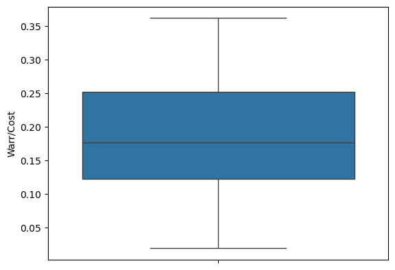

```python
features_train, median_new, mad_new = trim_outliers_new(features_train, ['Warr/Cost'])
sns.boxplot(features_train['Warr/Cost'])
```

```python
# The outliers have gone away, i.e. trimmed to three times the median absolute deviation
```

**Function for Feature Engineering, including merged categories and new feature**

```python
def engineer_features(df, top_categories=None, col_n=None):
    '''
    recoding features and adding new ones

    # Make: first four categories + all others as fifth = others
    # Size: first five categories + all others as sixth = others
    # Color: first five categories + all others as sixth = others

    # Recode using .apply und lambda
    # logical meaning:

    if x in Colortop5:
    return x        # keep value
    else:
        return 'other'  # replace value with 'other'

    Application: features_train, top_categories = engineer_features(features_train)
                features_test                  = engineer_features(features_test, top_categories)
    '''

    #recode features

    df = df.copy()

    if col_n is None:
        col_n = {
            'Make': 4,
            'Size':  5,
            'Color':  5
        }

    if top_categories is None:
        top_categories = {}
        for col, n in col_n.items():
            top_categories[col] = df[col].value_counts().nlargest(n).index.tolist()

    for col in col_n.keys():
        df[col] = df[col].apply(lambda x: x if x in top_categories[col] else 'other')

    # create new feature
    df['Warr/Cost'] = df['WarrantyCost'] / df['VehBCost']

    return df, top_categories
```

### Dimensionality Reduction

The EDA has shown that the features starting with ‘MMR…’ are all highly correlated (since they are all variants of some average prices for the type of car in question). Therefor it makes sense to remove the redundant information by performing a PCA (principal component analysis) and extracting the essence of the MMR features in just one feature. As the scree plot below indicates more than 90% of the original information can be conserved by extracting just one component (or: factor/dimension) that will replace all MMR features in modeling.

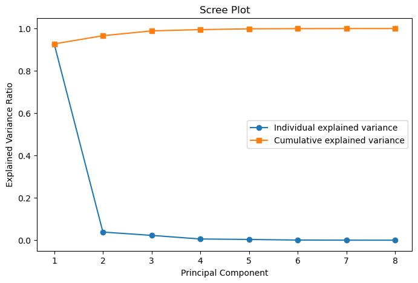

```python
features_mmr = ['MMRAcquisitionAuctionAveragePrice','MMRAcquisitionAuctionCleanPrice',
                'MMRAcquisitionRetailAveragePrice',
                'MMRAcquisitonRetailCleanPrice', 'MMRCurrentAuctionAveragePrice',
                'MMRCurrentAuctionCleanPrice', 'MMRCurrentRetailAveragePrice',
                'MMRCurrentRetailCleanPrice']

from sklearn.preprocessing import StandardScaler
from sklearn.decomposition import PCA
import matplotlib.pyplot as plt
import numpy as np

pipeline = Pipeline([('scale', StandardScaler()), ('pca', PCA())])

# fit pipeline
pipeline.fit(features_train[features_mmr])

# transform
pca_train = pipeline.transform(features_train[features_mmr])

# create column names
n_components = pipeline.named_steps['pca'].n_components_
pca_cols = [f'pca_{i}' for i in range(n_components)]

# add the new columns
features_train[pca_cols] = pca_train

# explained variance ratios
explained_var = pipeline.named_steps['pca'].explained_variance_ratio_

# cumulative explained variance
cum_var = np.cumsum(explained_var)

# scree plot
plt.figure(figsize=(8, 5))

plt.plot(
    range(1, len(explained_var) + 1),
    explained_var,
    marker='o',
    label='Individual explained variance'
)

plt.plot(
    range(1, len(cum_var) + 1),
    cum_var,
    marker='s',
    label='Cumulative explained variance'
)

plt.xlabel('Principal Component')
plt.ylabel('Explained Variance Ratio')
plt.title('Scree Plot')
plt.xticks(range(1, len(explained_var) + 1))
plt.legend()

plt.show()
```

```python
# One component can be extracted while conserving more than 90% of the information

pipeline = Pipeline([('scale', StandardScaler()), ('pca', PCA(n_components=0.9))])

# fit pipeline
pipeline.fit(features_train[features_mmr])

# transform
pca_train = pipeline.transform(features_train[features_mmr])
pca_test  = pipeline.transform(features_test[features_mmr])

# create column names
n_components = pipeline.named_steps['pca'].n_components_
pca_cols = [f'pca_{i}' for i in range(n_components)]

# add the new columns
features_train[pca_cols] = pca_train
features_test[pca_cols]  = pca_test
```

**Function for performing PCA on all MMR features**

```python
def pca_data (df, pca_pipeline=None):
    '''
    Performs PCA on MMR Variables to reduce to one dimension keeping 90% of the variance
    Perform after feature_engineering, before trim_outliers_new (use pca_cols as input)
    Application:
    features_train, pca_pipeline = pca_data(features_train)
    features_test                = pca_data(features_test, pca_pipeline)
    '''

    df = df.copy()

    if pca_pipeline is None:
        pca_pipeline = Pipeline([
            ('scale', StandardScaler()),
            ('pca',   PCA(n_components=0.9, svd_solver='full'))
        ])
        pca_pipeline.fit(df[features_mmr])  #fit

    # Transform
    pca_result = pca_pipeline.transform(df[features_mmr])
    n_components = pca_pipeline.named_steps['pca'].n_components_
    pca_cols = [f'pca_{i}' for i in range(n_components)]

    # Add component as new column, remove original MMR features
    df[pca_cols] = pca_result
    df = df.drop(columns=features_mmr)

    return df, pca_pipeline, pca_cols
```

### Train model

```python
#disable data conversion warnings
from sklearn.exceptions import DataConversionWarning
import warnings
warnings.filterwarnings(action='ignore', category=DataConversionWarning)
```

```python
#Modul import

from sklearn.pipeline import Pipeline
from sklearn.preprocessing import StandardScaler
from sklearn.decomposition import PCA

from scipy.stats import median_abs_deviation
import numpy as np

from sklearn.compose import ColumnTransformer
from sklearn.preprocessing import OneHotEncoder

from sklearn.preprocessing import MinMaxScaler
from sklearn.model_selection import GridSearchCV
from sklearn.ensemble import RandomForestClassifier
from sklearn.linear_model import LogisticRegression
from sklearn.metrics import f1_score, recall_score, precision_score, accuracy_score, confusion_matrix, classification_report
```

# **All Functions collected in one place**

```python
def clean_data(df, median=None, mode=None, mad=None, outlier_col=None):
    '''
    Function to select columns, transform data types, deal with missings and outliers
    input: features_train or features_test, median, mode, mad from train data if applied on test data;
            outlier_col: columns for which outliers shall be trimmed to 3 * mad
    output: clean features_train, ready for model training + median, mode, mad for usage on test data;
            clean features_test
    '''

    df = df.copy() # to prevent warnings

    from scipy.stats import median_abs_deviation

    # calculate median, mode and mad from train data
    if median is None:
        median = df.median(numeric_only=True)
    if mode is None:
        mode = df.mode().iloc[0]
    if mad is None:
        mad = df.select_dtypes(include='number').apply(median_abs_deviation)

    # format date time column
    df['PurchDate'] = pd.to_datetime(df['PurchDate'], unit='s')

    # remove unnecessary columns
    df = df.drop(columns=['Model', 'SubModel', 'Trim', 'Transmission', 'PRIMEUNIT', 'AUCGUART', 'WheelTypeID', 'BYRNO'])

    # change data type object in category
    feature_obj = ['Auction', 'Make', 'Color', 'WheelType',
              'Nationality', 'Size', 'TopThreeAmericanName', 'VNST']
    df[feature_obj] = df[feature_obj].astype('category')

    ### Deal with Missings

    # 1. Missings in WheelType as own category:
    df['WheelType'] = df['WheelType'].cat.add_categories('unknown').fillna('unknown')

    # 2. Replace missings in numerical features with median

        #before: set 0 and 1 Dollar as missings
    null_cols = ['MMRAcquisitionAuctionAveragePrice',
                'MMRAcquisitionAuctionCleanPrice', 'MMRAcquisitionRetailAveragePrice',
                'MMRAcquisitonRetailCleanPrice', 'MMRCurrentAuctionAveragePrice',
                'MMRCurrentAuctionCleanPrice', 'MMRCurrentRetailAveragePrice',
                'MMRCurrentRetailCleanPrice', 'VehBCost']

    import numpy as np
    df[null_cols] = df[null_cols].replace([0, 1], np.nan)

        # Replace missings of nummerical features with median (calculated from train data)
    df = df.fillna(median)

    # 3. Categorical features: replace missings with modus (calculated from train data)
    cat_cols = df.select_dtypes(include=['category']).columns
    df[cat_cols] = df[cat_cols].fillna(mode)

    # Trim Outliers (winsorizing) in VehBCost using median and mad from train data
    if outlier_col is not None:
        lower = median[outlier_col] - 3 * mad[outlier_col]
        upper = median[outlier_col] + 3 * mad[outlier_col]
        df[outlier_col] = df[outlier_col].clip(lower=lower, upper=upper)

    return df, median, mode, mad
```

```python
def engineer_features(df, top_categories=None, col_n=None):
    '''
    recoding features and adding new ones

    # Make: first four categories + all others as fifth = others
    # Size: first five categories + all others as sixth = others
    # Color: first five categories + all others as sixth = others

    # Recode using .apply und lambda
    # logical meaning:

    if x in Colortop5:
    return x        # keep value
    else:
        return 'other'  # replace value with 'other'

    Application: features_train, top_categories = engineer_features(features_train)
                features_test                  = engineer_features(features_test, top_categories)
    '''

    #recode features

    df = df.copy()

    if col_n is None:
        col_n = {
            'Make': 4,
            'Size':  5,
            'Color':  5
        }

    if top_categories is None:
        top_categories = {}
        for col, n in col_n.items():
            top_categories[col] = df[col].value_counts().nlargest(n).index.tolist()

    for col in col_n.keys():
        df[col] = df[col].apply(lambda x: x if x in top_categories[col] else 'other')

    # create new feature
    df['Warr/Cost'] = df['WarrantyCost'] / df['VehBCost']

    return df, top_categories
```

```python
def pca_data (df, pca_pipeline=None):
    '''
    Performs PCA on MMR Variables to reduce to one dimension keeping 90% of the variance
    Perform after feature_engineering, before trim_outliers_new (use pca_cols as input)
    Application:
    features_train, pca_pipeline = pca_data(features_train)
    features_test                = pca_data(features_test, pca_pipeline)
    '''

    df = df.copy()

    if pca_pipeline is None:
        pca_pipeline = Pipeline([
            ('scale', StandardScaler()),
            ('pca',   PCA(n_components=0.9, svd_solver='full'))
        ])
        pca_pipeline.fit(df[features_mmr])  #fit

    # Transform
    pca_result = pca_pipeline.transform(df[features_mmr])
    n_components = pca_pipeline.named_steps['pca'].n_components_
    pca_cols = [f'pca_{i}' for i in range(n_components)]

    # Add component as new column, remove original MMR features
    df[pca_cols] = pca_result
    df = df.drop(columns=features_mmr)

    return df, pca_pipeline, pca_cols
```

```python
# Creating a function to trim outliers in Warr/Cost and the other new feature 'pca_cols' (see below in dimension reduction)
def trim_outliers_new(df, col, median=None, mad=None):
    '''
    Trims outliers of new features after (!) engineer function on train and test data

    col: List of columns

    procedure as in clean_data: fit only with info from train, transform train and test

    Application: features_train, median_new, mad_new = trim_outliers_new(features_train, ['col1', 'col2'])
        features_test                              = trim_outliers_new(features_test, ['col1', 'col2'],
                                                                        median_new, mad_new)
    '''

    df = df.copy()

    if median is None:
        median = df[col].median()

    from scipy.stats import median_abs_deviation

    if mad is None:
        mad = df[col].apply(median_abs_deviation)

    for c in col:
        lower = median[c] - 3 * mad[c]
        upper = median[c] + 3 * mad[c]
        df[c] = df[c].clip(lower=lower, upper=upper)

    return df, median, mad
```

```python
def transform_features(df, cat_cols, num_cols, ct=None):
    '''
    Transforms features using OneHotEncoder for categorical and StandardScaler for numerical columns.

    cat_cols and num_cols have to be defined beforehand

    Application: features_train_t, ct = transform_features(features_train, cat_cols, num_cols)
               features_test_t, _  = transform_features(features_test, cat_cols, num_cols, ct)
    '''

    if ct is None:
        ct = ColumnTransformer(transformers=[
            ('onehot', OneHotEncoder(handle_unknown='ignore', sparse_output=False), cat_cols),
            ('scale',  StandardScaler(), num_cols)
        ], remainder='drop')
        df_transformed = ct.fit_transform(df)
    else:
        df_transformed = ct.transform(df)

    # resemble column names
    ohe_cols = ct.named_transformers_['onehot'].get_feature_names_out(cat_cols)
    all_cols = list(ohe_cols) + list(num_cols)

    # create data frame
    df_transformed = pd.DataFrame(df_transformed, columns=all_cols)

    return df_transformed, ct
```

```python
# Order of functions

#1. gathering data

import pandas as pd
df = pd.read_csv('data_train.csv')

#2. Split

from sklearn.model_selection import train_test_split

features = df.drop(columns='IsBadBuy')
target = df['IsBadBuy']
features_train, features_test, target_train, target_test = train_test_split(features, target,
                                                                            random_state = 42, test_size = 0.1)

#3. Functions and list definitions:

    #cleaning feature_train data
features_train, median, mode, mad = clean_data(features_train, outlier_col='VehBCost')

    #feature engineering on train data
features_train, top_categories = engineer_features(features_train)

    #performing PCA on MMR variables in train data

features_mmr = ['MMRAcquisitionAuctionAveragePrice','MMRAcquisitionAuctionCleanPrice',
                'MMRAcquisitionRetailAveragePrice',
                'MMRAcquisitonRetailCleanPrice', 'MMRCurrentAuctionAveragePrice',
                'MMRCurrentAuctionCleanPrice', 'MMRCurrentRetailAveragePrice',
                'MMRCurrentRetailCleanPrice']

features_train, pca_pipeline, pca_cols = pca_data(features_train)

    #trimming outliers of new features generated through engineering and PCA

outlier_cols = ['Warr/Cost'] + pca_cols

features_train, median_new, mad_new = trim_outliers_new(features_train, outlier_cols)

    #performing the same steps on test data (only transform, not fit)

features_test, _ , _ , _ = clean_data(features_test, median, mode, mad, outlier_col='VehBCost')
features_test, _  = engineer_features(features_test, top_categories)
features_test, _ , _ = pca_data(features_test, pca_pipeline)
features_test, _ , _ = trim_outliers_new(features_test, outlier_cols, median_new, mad_new)


#4. Transform Data: OneHot Encoding and StandardScaler

cat_cols = ['Auction', 'Make', 'Color', 'WheelType', 'Nationality', 'Size', 'TopThreeAmericanName']
num_cols = ['VehYear', 'VehicleAge', 'VehOdo', 'VehBCost', 'WarrantyCost', 'Warr/Cost', 'pca_0']

features_train, ct = transform_features(features_train, cat_cols, num_cols)
features_test, _  = transform_features(features_test, cat_cols, num_cols, ct)

### Data reading for modeling ###

# Save parameters for later use on aim data set
params = {
    'median':         median,
    'mad':            mad,
    'mode':           mode,
    'top_categories': top_categories,
    'pca_pipeline':   pca_pipeline,
    'median_new':     median_new,
    'mad_new':        mad_new,
    'ct':             ct
}

import joblib
joblib.dump(params, 'all_params.joblib')
```

```
['all_params.joblib']
```